# The Merchants are in Business: A Comedy

### Corpus Summary

We will begin this section by prepping our table for sentiment analysis and carrying out various visualization functions along the way.

#### Cleaning and Appending Information

We currently have sentiment per sentence and the entities located in those sentences. The problem is that that the entities are actually a bit distorted. Some are actually duplicates, some are not entities at all. Before we make the final tally, we have to manually scrub the data set using Microsoft Excel.

Also since our analysis is a bit time based, we will mention the years of first publication and performance along with the titles.

```r
clean_entities <- read.csv("backup_(final_entities).csv", stringsAsFactors = FALSE)

clean_entities$year[clean_entities$title == "The Dutch Lover"] <- "1673"
clean_entities$year[clean_entities$title == "The Plain Dealer"] <- "1676"
clean_entities$year[clean_entities$title == "The Gentlemen Dancing-Master"] <- "1673"
clean_entities$year[clean_entities$title == "The Recruiting Officer"] <- "1706"
clean_entities$year[clean_entities$title == "The Roundheads"] <- "1682"
clean_entities$year[clean_entities$title == "The Way of the World"] <- "1700"
clean_entities$year[clean_entities$title == "Venice Preserved: A Tragedy"] <- "1682"
clean_entities$year[clean_entities$title == "Amboyna"] <- "1673"
clean_entities$year[clean_entities$title == "Love for Love: A Comedy"] <- "1695"
clean_entities$year[clean_entities$title == "Aureng-Zebe"] <- "1675"

clean_entities$title[clean_entities$title == "The Dutch Lover"] <- "The Dutch Lover - 1673"
clean_entities$title[clean_entities$title == "The Plain Dealer"] <- "The Plain Dealer - 1676"
clean_entities$title[clean_entities$title == "The Gentlemen Dancing-Master"] <- "The Gentlemen Dancing-Master - 1673"
clean_entities$title[clean_entities$title == "The Recruiting Officer"] <- "The Recruiting Officer - 1706"
clean_entities$title[clean_entities$title == "The Roundheads"] <- "The Roundheads - 1682"
clean_entities$title[clean_entities$title == "The Way of the World"] <- "The Way of the World - 1700"
clean_entities$title[clean_entities$title == "Venice Preserved: A Tragedy"] <- "Venice Preserved - 1682"
clean_entities$title[clean_entities$title == "Amboyna"] <- "Amboyna - 1673"
clean_entities$title[clean_entities$title == "Love for Love: A Comedy"] <- "Love for Love - 1695"
clean_entities$title[clean_entities$title == "Aureng-Zebe"] <- "Aureng-Zebe - 1675"

head(clean_entities)
```

|  | X.1 | X | author | title | words | sentence_nr | entity | kind | year |
| --- | --- | --- | --- | --- | --- | --- | --- | --- | --- |
| 1 | NA | NA |  |  |  | NA |  |  | NA |
| 2 | 2 | 165 | Congreve, William | Love for Love - 1695 | displeasure by his expensive way of living in love with Angelica SCANDAL his friend a free speaker Mr Smith | 54 | Angelica | person | 1695 |
| 3 | 3 | 184 | Congreve, William | Love for Love - 1695 | and positive superstitious and pretending to understand astrology palmistry physiognomy omens dreams etc uncle to Angelica JEREMY servant to Valentine Mr Bowen | 58 | Angelica | person | 1695 |
| 4 | 4 | 276 | Congreve, William | Love for Love - 1695 | Ill pursue Angelica with more love than ever and appear more notoriously her admirer in this restraint than when I openly rivalled the rich fops that made court to her | 116 | Angelica | person | 1695 |
| 5 | 5 | 626 | Congreve, William | Love for Love - 1695 | This was once proposed before and I refused it but the present impatience of my creditors for their money and my own impatience of confinement and absence from Angelica force me to consent | 382 | Angelica | person | 1695 |
| 6 | 6 | 631 | Congreve, William | Love for Love - 1695 | A very desperate demonstration of your love to Angelica and I think she has never given you any assurance of hers | 384 | Angelica | person | 1695 |

```r
NA
```

#### Character Occurrences

Now that we have a clean dataframe with all captured entities, we can observe the most active characters in every text.

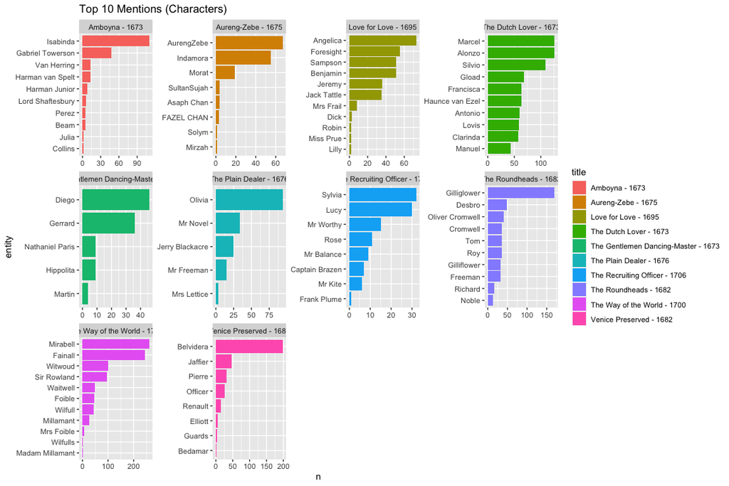

```r
# Calculating total occurences of a character.
occurences <- clean_entities %>% count(title, kind, entity)

occurences %>%
  group_by(title) %>%
  filter(kind == "person") %>%
  top_n(10) %>%
  mutate(entity = reorder(entity, n)) %>%
  ggplot(aes(entity, y = n, fill = title)) +
  geom_col() +
  facet_wrap( ~ title, scales = "free") +
  ggtitle("Top 10 Mentions (Characters)") +
  coord_flip()
```

#### Length of Plays

To gether some statistical info on the length of the plays, let us plot the total words used in each text.

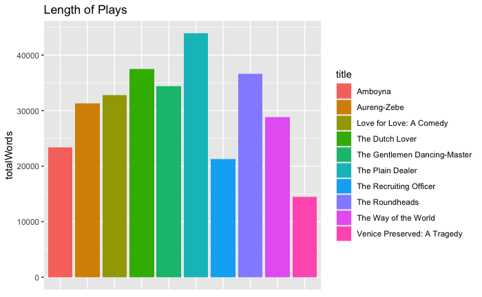

```r
unnest_corpus <- corpus_clean %>%
  unnest_tokens(word, text)

# Calculating total words in a text
wordCount <- unnest_corpus %>%
  count(title)
colnames(wordCount) <- c("title", "totalWords")

ggplot(wordCount, aes(x = title, y = totalWords, fill = title)) +
  geom_col() +
  ggtitle("Length of Plays") +
  theme(axis.title.x=element_blank(),
        axis.text.x=element_blank(),
        axis.ticks.x=element_blank())
```

#### Word Frequency

Another attempt at gaining insight from the frequency of particular words, we can map out the most positive and negative words that show up in our corpus of Restoration Literature. What about most frequently occuring words with no positive-negatve filter?

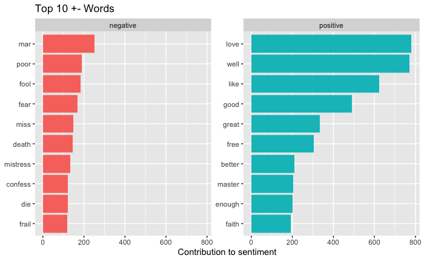

```r
# Top 10 + and - words.

bing_word_counts <- unnest_corpus %>%
  inner_join(get_sentiments("bing")) %>%
  count(word, sentiment, sort = TRUE) %>%
  ungroup()
bing_word_counts %>%
  group_by(sentiment) %>%
  top_n(10) %>%
  ungroup() %>%
  mutate(word = reorder(word, n)) %>%
  ggplot(aes(word, n, fill = sentiment)) +
  geom_col(show.legend = FALSE) +
  facet_wrap(~sentiment, scales = "free_y") +
  labs(y = "Contribution to sentiment",
       x = NULL) +
  ggtitle("Top 10 +- Words") +
  coord_flip()
```

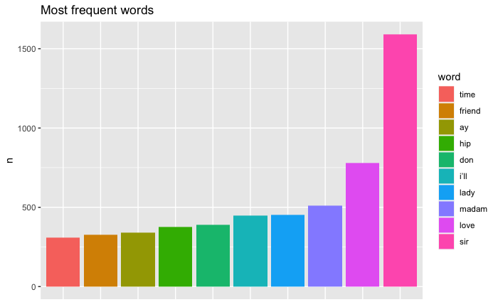

```r
# Top 10 words in restoration literature.

# Anti-joining stop words
word_freq <- unnest_corpus %>%
  anti_join(stop_words, by = c("word" = "word")) %>%
  filter(!(word %in% c("thee", "thou", "i'll", "nay", "tis", "ha", "enter", "exit", "scene", "act", "em", "mons", "thy") )) %>%
  count(word, sort = TRUE) %>%
  ungroup()

word_freq %>%
  mutate(word = reorder(word, n)) %>%
  top_n(10) %>%
  ggplot(aes(x = word, y = n, fill = word)) +
    geom_col() +
    ggtitle("Most frequent words") +
    theme(axis.title.x=element_blank(),
          axis.text.x=element_blank(),
          axis.ticks.x=element_blank())
```

### NLP, NER and Sentiment Analysis

```r
entities_unnest <- clean_entities %>%
  unnest_tokens(word, words)

entities_sentiment <- entities_unnest %>%
  group_by(author, title) %>%
  inner_join(get_sentiments("nrc")) %>%
  count(sentence_nr, sentiment) %>%
  spread(sentiment, n, fill = 0) %>%
  mutate(sentiment = positive - negative)

entities_matches_sentiment <- entities_unnest %>%
  inner_join(entities_sentiment) %>%
  distinct_at(vars(-word)) %>%
  left_join(occurences, by=c("title", "entity", "kind"))

ner_total_sentiment <- entities_matches_sentiment %>%
                           group_by(author, title, entity, kind, year) %>%
                           summarise(total = mean(sentiment))
```

## Data Visualization 1

#### Top 10 Locations

The `ner_total_sentiment` dataframe allows us to chart the top 10 locations based on their positive and negative sentiments.

##### Positive Locations

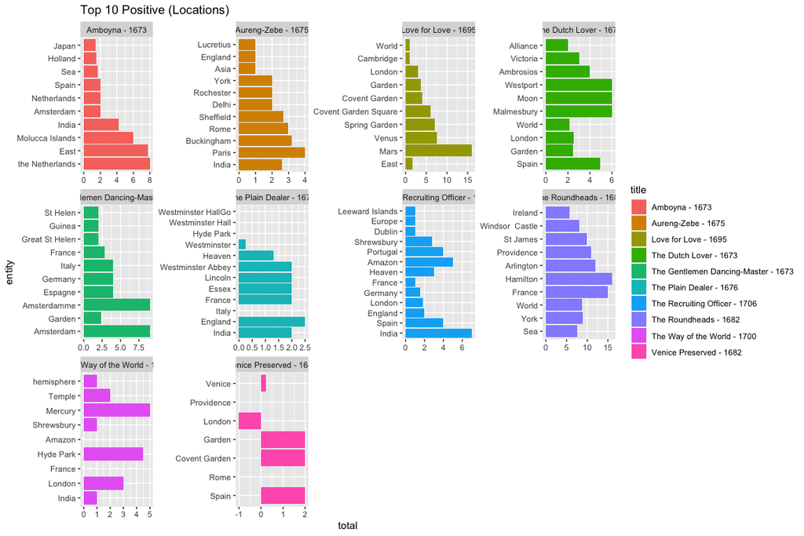

```r
ner_total_sentiment %>%
  group_by(title) %>%
  filter(kind == "location") %>%
   top_n(10) %>%
 mutate(entity = reorder(entity, (desc(total)))) %>%
  ggplot(aes(entity, y = total, fill = title)) +
  geom_col() +
  facet_wrap( ~ title, scales = "free") +
  ggtitle("Top 10 Positive (Locations)") +
  coord_flip()
```

##### Negative Locations

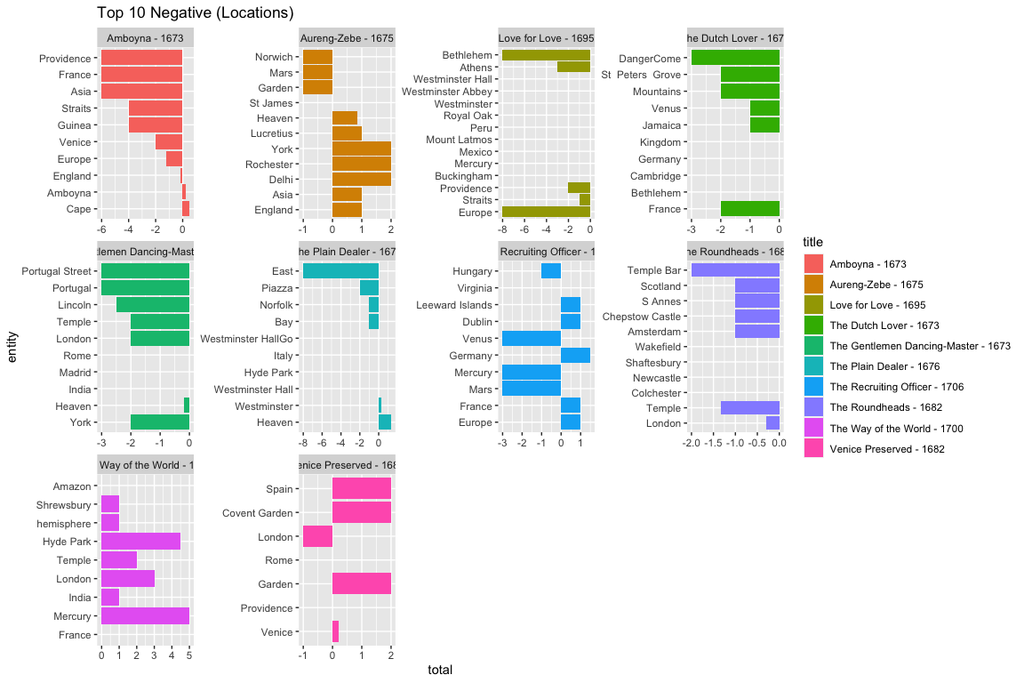

```r
ner_total_sentiment %>%
  group_by(title) %>%
  filter(kind == "location") %>%
   top_n(-10) %>%
 mutate(entity = reorder(entity, (desc(total)))) %>%
  ggplot(aes(entity, y = total, fill = title)) +
  geom_col() +
  facet_wrap( ~ title, scales = "free") +
  ggtitle("Top 10 Negative (Locations)") +
  coord_flip()
```

#### Drawbacks

One would expect France to be a consistently negative location considering the fierce trade rivalry between England and France in the Restoration era. However, France shows up as a positive location in 4 plays and a negative location in only 2 plays. There’s also no clear reason as to why London shows up as a negative location in 3 plays. Generic places like ‘garden’, ‘world’, ‘hemisphere’ and names of planets showing up on the mapping wasn’t helpful. While the positive/negative analysis does support our thesis to an extent, we didn’t observe a change in pattern between early and late restoration period. Thus, it’s not clear whether the treatment of trade in restoration plays became more positive over time.

### Data Visualization 2

#### Top 10 Characters

The `ner_total_sentiment` dataframe allows us to chart the top 10 characters based on their positive and negative sentiments.

##### Positive Charcters

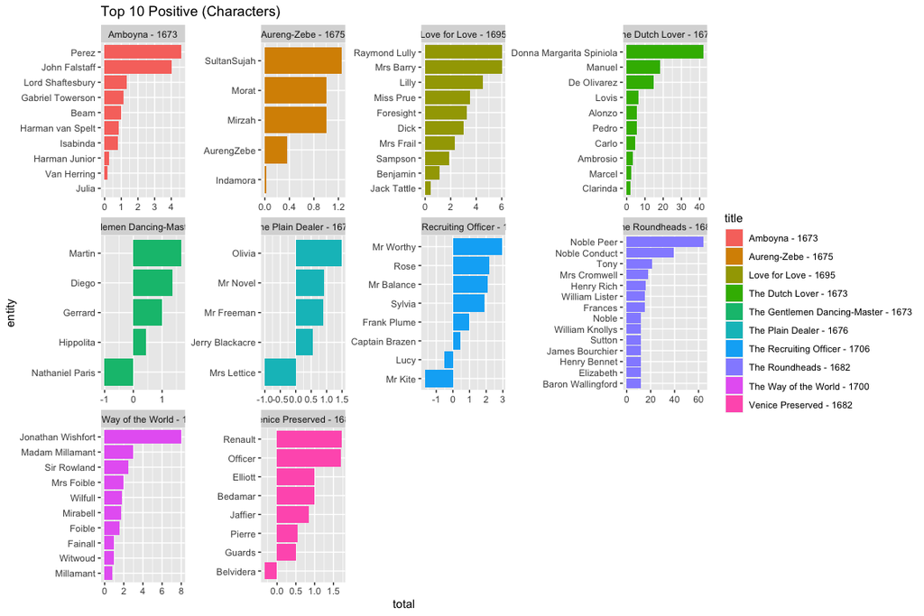

```r
ner_total_sentiment %>%
  arrange(year) %>%
  group_by(title) %>%
  filter(kind == "person") %>%
  top_n(10) %>%
  mutate(entity = reorder(entity, total)) %>%
  ggplot(aes(entity, y = total, fill = title)) +
  geom_col() +
  facet_wrap( ~ title, scales = "free") +
  ggtitle("Top 10 Positive (Characters)") +
  coord_flip()
```

##### Negative Charcters

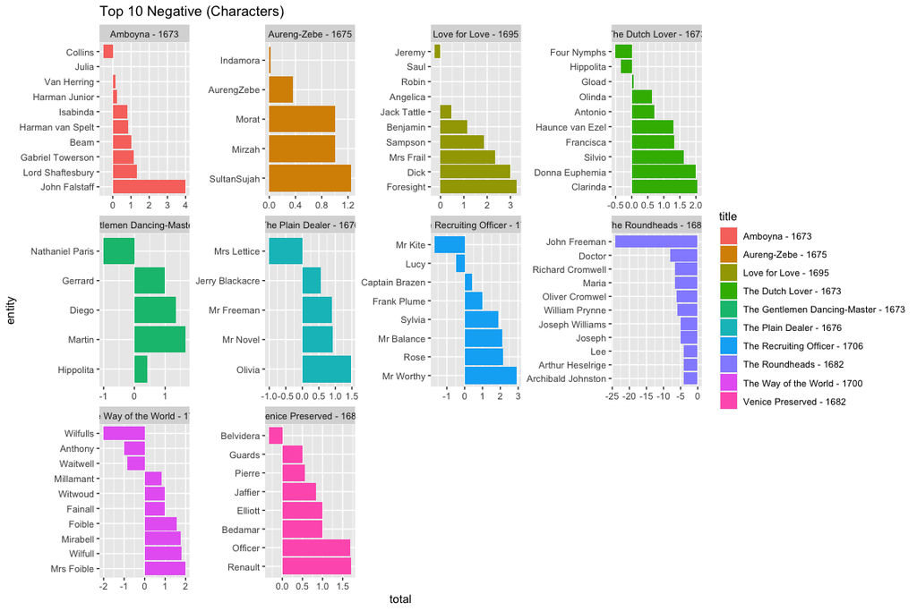

```r
ner_total_sentiment %>%
  group_by(title) %>%
  filter(kind == "person") %>%
  top_n(-10) %>%
  mutate(entity = reorder(entity, desc(total))) %>%
  ggplot(aes(entity, y = total, fill = title)) +
  geom_col() +
  facet_wrap( ~ title, scales = "free") +
  ggtitle("Top 10 Negative (Characters)") +
  coord_flip()
```

We visualised the top ten positive and negative characters in every play. We then looked at the occupation of these characters to see how the merchant class was faring. Major positive characters in Amboyna belong to the merchant class. The protagonist Gabriel Towerson, both a ship captain and trader, is a positive character (positive factor 1). Isabinda (positive factor 1) , engaged to Towerson, is the daughter of merchants in India. The character ‘Beam’ is an english merchant whose positive factor is 1.

#### Drawbacks

This visualization proved elusive and tedious when it came to drawing conclusions to support our hypothesis. Characters showing up on the visualisation had to be looked at individually in their context to figure out their occupation. These occupations aren’t well defined in the plays (characters are defined in terms of their relation to other characters instead, ex: son of governor etc.) and don’t cleanly divide themselves into either royalty or the merchant class. This means that some plays in the corpus couldn’t be factored into our analysis. Most women in the plays don’t have an occupation, however, some can be related to people in the merchant class. These relationships, though relevant to our analysis, are extremely hard to track.

### Reflections

One of the bigger challenges we faced with our corpus was data cleaning. The raw data had a lot of errors that were hard to catch. Unusual names of characters like Foresight and Tattle couldn’t be detected or were coded as locations which we accidentally deleted and had to input later on. The occurrence of a character name in R was lower than its actual occurrence since the plays used name abbreviations before dialogues. So negative/positive analysis depends on the count of entrance and exit of a character from the scene. We encountered a bug where a character name from one play, Belvedira, was showing up in the data frame of most plays in our corpus.

Analysis in R allowed us to ask more in-depth questions about the corpus as opposed to Voyant where analysis depended largely on word analysis divorced from its context. While sentiment analysis opened up new avenues for us, we aren’t sure if it was the most appropriate visualization for our hypothesis.